# Power analysis

Miriam Schulz

2024-12-13

```r
library(lme4)
library(lmerTest)
library(designr)
library(dplyr)
library(ggplot2)
rm(list = ls())
```

# 1 About

Power analysis for the Cloze Prediction & Production experiment.

## 1.1 Design

A 2 x 2 target manipulation design.

Dependent variable: RTs.

Predictor variables

- Expectancy (high vs. low)
- Task (Cloze production vs. reading comprehension only)

# 2 A first simulation with exaggerated effects

## 2.1 Creating the data set

```r
set.seed(42)

design <-
  fixed.factor("Expectancy", levels=c("High", "Low")) +
  fixed.factor("Task", levels=c("Production", "Comprehension")) +
  random.factor("Item", instances=20) +
  random.factor("Subj", instances=10) +
  random.factor(c("Subj", "Item"), groups=c("Expectancy", "Task"))
dat <- dplyr::arrange(design.codes(design), Subj, Item)
length(unique(dat$Item)) # number of items
```

```
## [1] 80
```

```r
length(unique(dat$Subj)) # number of subjects
```

```
## [1] 40
```

```r
# convert to factor
dat <- dat %>% mutate(across(all_of(colnames(dat)), ~ as.factor(.)))

# set contrasts
contrasts(dat$Expectancy) <- c(-0.5, 0.5)
contrasts(dat$Task) <- c(-0.5, 0.5)
```

## 2.2 Simulating the response variable

Define the mean (intercept), effect size for each effect, and the random effects and residual variation, then use `simLMM()` to generate random data fulfilling these criteria as a response variable:

```r
# Specify fixed effects coefficients for:
# Intercept, Expectancy, Task, Exp:Task Interaction
fix <- c(250, 40, 20, 10)

# Specify random effects + res variance
sd_Subj <- c(20, 10, 10)
sd_Item <- c(10, 10, 10)
sd_Res  <- 50

dat$RTsim <- simLMM(form = ~ 1 + Expectancy * Task +
                      (1 + Expectancy + Task | Subj) +
                      (1 + Expectancy + Task | Item),
                   data   = dat,                     # data
                   Fixef  = fix,                     # fixed effects
                   VC_sd  = list(sd_Subj, sd_Item, sd_Res),   # random effects and noise (error) SD
                   CP = 0.3,                         # correlation parameters of the random effects
                   empirical = TRUE)
```

```
## Data simulation from a linear mixed-effects model (LMM)
## Formula: gaussian ~ 1 + Expectancy1 + Task1 + Expectancy1:Task1 + ( 1 + Expectancy1 + Task1 | Subj ) + ( 1 + Expectancy1 + Task1 | Item )
## empirical = TRUE
## Random effects:
##  Groups    Name          Std.Dev. Corr
##  Subj      (Intercept)   20.0
##            Expectancy1   10.0     0.30
##            Task1         10.0     0.30   0.30
##  Item      (Intercept)   10.0
##            Expectancy1   10.0     0.30
##            Task1         10.0     0.30   0.30
##  Residual                50.0
## Number of obs: 3200, groups:  Subj, 40; Item, 80
## Fixed effects:
##       (Intercept)       Expectancy1             Task1 Expectancy1:Task1
##               250                40                20                10
```

Sanity check: Do the fixed effects in the data set correspond to the constraints defined above? (If `empirical = TRUE` is used above, this should correspond *exactly* to the constaints.)

```r
dat %>% group_by(Expectancy) %>% summarize(M=mean(RTsim))
```

```
## # A tibble: 2 × 2
##   Expectancy     M
##   <fct>      <dbl>
## 1 High         230
## 2 Low          270
```

```r
dat %>% group_by(Task) %>% summarize(M=mean(RTsim))
```

```
## # A tibble: 2 × 2
##   Task              M
##   <fct>         <dbl>
## 1 Production      240
## 2 Comprehension   260
```

Run an LMM to verify that this in effect yields the right estimates:

```r
# Interaction model
m_interaction <- lmer(RTsim ~ 1 + Expectancy * Task +
                      (1 + Expectancy + Task || Subj) +
                      (1 + Expectancy + Task || Item),
          data = dat, control=lmerControl(calc.derivs=FALSE))

save(m_interaction, file="model_test.rda")
```

```r
load(file="model_test.rda")
summary(m_interaction)
```

```
## Linear mixed model fit by REML. t-tests use Satterthwaite's method [
## lmerModLmerTest]
## Formula: RTsim ~ 1 + Expectancy * Task + (1 + Expectancy + Task || Subj) +
##     (1 + Expectancy + Task || Item)
##    Data: dat
## Control: lmerControl(calc.derivs = FALSE)
##
## REML criterion at convergence: 34368.8
##
## Scaled residuals:
##     Min      1Q  Median      3Q     Max
## -3.4930 -0.6795  0.0059  0.6751  3.3083
##
## Random effects:
##  Groups   Name              Variance  Std.Dev.  Corr
##  Item     TaskProduction    0.000e+00  0.000000
##           TaskComprehension 1.285e+02 11.335855  NaN
##  Item.1   ExpectancyHigh    4.937e+01  7.026082
##           ExpectancyLow     9.775e+01  9.886615 1.00
##  Item.2   (Intercept)       1.013e-05  0.003183
##  Subj     TaskProduction    8.828e+01  9.395858
##           TaskComprehension 1.555e+02 12.471006 0.51
##  Subj.1   ExpectancyHigh    0.000e+00  0.000000
##           ExpectancyLow     2.181e+02 14.768267  NaN
##  Subj.2   (Intercept)       2.460e+02 15.682871
##  Residual                   2.498e+03 49.981108
## Number of obs: 3200, groups:  Item, 80; Subj, 40
##
## Fixed effects:
##                   Estimate Std. Error       df t value Pr(>|t|)
## (Intercept)        250.000      3.443   46.185  72.615  < 2e-16 ***
## Expectancy1         40.000      2.946   39.260  13.579  < 2e-16 ***
## Task1               20.000      2.804   49.146   7.134 4.05e-09 ***
## Expectancy1:Task1   10.000      3.534 2934.866   2.829  0.00469 **
## ---
## Signif. codes:  0 '***' 0.001 '**' 0.01 '*' 0.05 '.' 0.1 ' ' 1
##
## Correlation of Fixed Effects:
##             (Intr) Expct1 Task1
## Expectancy1 0.299
## Task1       0.170  0.000
## Expctnc1:T1 0.000  0.000  0.000
## optimizer (nloptwrap) convergence code: 0 (OK)
## boundary (singular) fit: see help('isSingular')
```

# 3 Power analysis

## 3.1 Run power analysis

To simulate many data sets, write a function that generates a new data frame for a given number of items and subjects:

```r
generate_dataframe <- function(n_subj, n_items) {

  # Generate Latin Square design
  design <-
    fixed.factor("Expectancy", levels=c("High", "Low")) +
    fixed.factor("Task", levels=c("Production", "Comprehension")) +
    random.factor("Item", instances=n_items/4) +
    random.factor("Subj", instances=n_subj/4) +
    random.factor(c("Subj", "Item"), groups=c("Expectancy", "Task"))
  dat <- dplyr::arrange(design.codes(design), Subj, Item)

  # Convert to factor
  dat <- dat %>% mutate(across(all_of(colnames(dat)), ~ as.factor(.)))

  # Set contrasts
  contrasts(dat$Expectancy) <- c(-0.5, 0.5)
  contrasts(dat$Task) <- c(-0.5, 0.5)

  return(dat)
}
```

Define a function for the power analysis:

```r
power_analysis <- function(dat,
                           mean_rt,
                           expectancy_fixed, task_fixed, interaction_fixed,
                           n_subj, n_items,
                           verbose=FALSE) {

  for (s in 1:length(n_subj)) {

    cat("SIMULATION NO. ", s, "/", length(n_subj), sep=" ", end="\n")

    for (i in 1:length(n_items)) {

      dat <- generate_dataframe(n_subj[s], n_items[i])
      nsj <- length(unique(dat$Subj))
      nit <- length(unique(dat$Item))

      if (verbose == TRUE) {
        cat("   Unique subjects:", length(unique(dat$Subj)), sep=" ", end="\n")
        cat("   Unique items:   ", length(unique(dat$Item)), sep=" ", end="\n")
      }

      for (e in 1:length(expectancy_fixed)) {
        exp <- expectancy_fixed[e]

        for (t in 1:length(task_fixed)) {
          task <- task_fixed[t]

          for (ia in 1:length(interaction_fixed)) {
            interact <- interaction_fixed[ia]

            if (verbose == TRUE) {
              cat("      Expectancy: ", exp, sep=" ", end="\n")
              cat("      Task:       ", task, sep=" ", end="\n")
              cat("      Interaction:", interact, sep=" ", end="\n")
            }

            fix <- c(mean_rt, exp, task, interact)

            # For each iteration, run several simulations for more stable results
            for (j in 1:10) {

              # Simulate the response variable
              dat$RTsim <- simLMM(
                form = ~ 1 + Expectancy * Task +
                  (1 + Expectancy + Task | Subj) +
                  (1 + Expectancy + Task | Item),
                data   = dat,
                Fixef  = fix,
                VC_sd  = list(sd_Subj, sd_Item, sd_Res),
                CP     = 0.3,
                empirical = FALSE,
                verbose = FALSE
              )

              #ww <- ""  # init

              # Run an LMM
              suppressMessages(
                suppressWarnings(LMM <- withCallingHandlers({
                  lmer(
                    RTsim ~ 1 + Expectancy * Task +
                      # (1 + Expectancy + Task || Subj) +
                      # (1 + Expectancy + Task || Item),
                      (1 | Subj) +
                      (1 | Item),
                    data = dat,
                    REML = FALSE,
                    control = lmerControl(calc.derivs = FALSE)
                  )
                }#,
                #warning = function(w) { ww <<- w$message }
              )))

              # Append the LMM estimates to the COF data frame
              LMMcof <- coef(summary(LMM))
              COF <- rbind(
                COF,
                c(nsj, nit, exp, task, interact,
                  LMMcof["Expectancy1", ], LMMcof["Task1", ],
                  LMMcof["Expectancy1:Task1", ],
                  isSingular(LMM))
              )
              #warn[s] <- ww
            }
          }
        }
      }
    }
    beepr::beep()  # beep once the current batch of subjects is finished
  }
  #COF$warning <- warn
  return(COF)
}
```

Set the fixed and random effects, and initialize:

```r
# Define a mean RT (intercept)
mean_rt <- 250  # intercept

# Define fixed effects for Expectancy and Task (vectors of same length)
# and their interaction.
# Note that these vectorsmust be the SAME length, but one can vary
# which fixed effect to test by keeping the values in the vectors for the other
# effects constant, e.g., task_fixed <- c(5, 5, 5).
expectancy_fixed <- c(5, 10)  # simulation values for expectancy
task_fixed <- c(3, 5)  # simulation values for task
interaction_fixed <- c(5, 7.5, 10)  # simulation values for exp:task interaction

# Define random effects and variance
sd_Subj <- c(30, 10, 10)
sd_Item <- c(30, 10, 10)
sd_Res  <- 50

# Define vectors for the number of subjects and items to simulate
n_subj <- seq(8, 96, 8)
n_items <- seq(80, 96, 8)

COF <- data.frame()
#warn <- c()
```

Run power analysis and format power analysis data frame:

```r
# set.seed(666)
set.seed(42)
COF <- power_analysis(dat,
                      mean_rt,
                      expectancy_fixed, task_fixed, interaction_fixed,
                      n_subj, n_items,
                      verbose = FALSE)
#warn <- power_output[2]

# Results for LMMs
names(COF) <- c("nsj", "nit", "exp", "task", "interact",
                "Expectancy", "SE1", "df1", "t1", "p1",
                "Task", "SE2", "df2", "t2", "p2",
                "Interaction", "SE3", "df3", "t3", "p3",
                "singular")
#COF$warning <- warn
#COF$noWarning <- warn==""
COF$sign1   <- as.numeric(COF$p1 < .05) # determine significant results; one-tailed
COF$sign2   <- as.numeric(COF$p2 < .05) # Significant results for Task
COF$sign3   <- as.numeric(COF$p3 < .05) # Significant results for Task

COF$nsjF   <- gtools::quantcut(COF$nsj, q=seq(0,1,length=10))
COF$nsjFL  <- plyr::ddply(COF,"nsjF",transform,nsjFL=mean(nsj))$nsjFL

save(COF, file="power.rda")
```

## 3.2 Plot power results

```r
load(file="power.rda")
```

Generate some subsetted data frames for plotting:

```r
# Extract only maximal fixed effects
COF_large_effects <- COF %>%
  filter(exp == max(exp)) %>%
  filter(task == max(task)) %>%
  filter(interact == max(interact))

# Extract only minimal fixed effects
COF_small_effects <- COF %>%
  filter(exp == min(exp)) %>%
  filter(task == min(task)) %>%
  filter(interact == min(interact))
```

### 3.2.1 Power by N of subjects

```r
power_plots_subjects <- function(dat) {

  # Extract maximal y axis range to make the two plots comparable side by side
  y_range <- range(c(dat$sign1, dat$sign2, dat$sign3), na.rm = TRUE)

  # Visualize results for Expectancy
  p1 <- ggplot(data = dat) +
    geom_smooth(aes(x = nsj, y = sign1), method="loess") +
    geom_point(   stat = "summary", aes(x = nsjFL, y = sign1), fun.data = mean_se) +
    geom_errorbar(stat = "summary", aes(x = nsjFL, y = sign1), fun.data = mean_se) +
    geom_line(    stat = "summary", aes(x = nsjFL, y = sign1), fun.data = mean_se) +
    geom_hline(yintercept = 0.8, color = "red", linetype = "dashed") +
    geom_hline(yintercept = 1, color = "darkgreen", linetype = "solid") +
    ggtitle("Power for Expectancy") +
    theme_minimal()

  # Visualize results for Task
  p2 <- ggplot(data = dat) +
    geom_smooth(aes(x = nsj, y = sign2), method="loess") +
    geom_point(   stat = "summary", aes(x = nsjFL, y = sign2), fun.data = mean_se) +
    geom_errorbar(stat = "summary", aes(x = nsjFL, y = sign2), fun.data = mean_se) +
    geom_line(    stat = "summary", aes(x = nsjFL, y = sign2), fun.data = mean_se) +
    geom_hline(yintercept = 0.8, color = "red", linetype = "dashed") +
    geom_hline(yintercept = 1, color = "darkgreen", linetype = "solid") +
    ggtitle("Power for Task") +
    theme_minimal()

  # Visualize results for the Expectancy:Task interaction
  p3 <- ggplot(data = dat) +
    geom_smooth(aes(x = nsj, y = sign3), method="loess") +
    geom_point(   stat = "summary", aes(x = nsjFL, y = sign3), fun.data = mean_se) +
    geom_errorbar(stat = "summary", aes(x = nsjFL, y = sign3), fun.data = mean_se) +
    geom_line(    stat = "summary", aes(x = nsjFL, y = sign3), fun.data = mean_se) +
    geom_hline(yintercept = 0.8, color = "red", linetype = "dashed") +
    geom_hline(yintercept = 1, color = "darkgreen", linetype = "solid") +
    ggtitle("Power for the Interaction") +
    theme_minimal()

  p1 <- p1 + coord_cartesian(ylim = y_range)
  p2 <- p2 + coord_cartesian(ylim = y_range)
  p3 <- p3 + coord_cartesian(ylim = y_range)

  suppressMessages({
    gridExtra::grid.arrange(p1, p2, p3, nrow = 1)
  })

}
```

Plot for the maximal number of items:

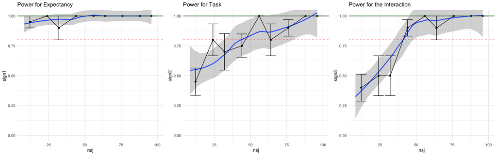

```r
# Plot for the maximal effects + max n of items
COF_subjects <- filter(COF_large_effects, nit == max(nit))
power_plots_subjects(COF_subjects)
```

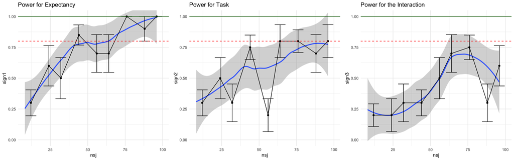

```r
# Plot for the smallest effects + max n of items
COF_subjects <- filter(COF_small_effects, nit == max(nit))
power_plots_subjects(COF_subjects)
```

### 3.2.2 Power by N of subjects & N of items

```r
power_plots_items <- function(dat) {

  # Extract maximal y axis range to make the two plots comparable side by side
  y_range <- range(c(dat$sign1, dat$sign2, dat$sign3), na.rm = TRUE)

  p1 <- ggplot(data=dat) +
    geom_smooth(aes(x=nsj, y=sign1, colour=factor(nit), fill=factor(nit)),
                method="loess", se=FALSE)+
    geom_point(   stat="summary", aes(x=nsjFL, y=sign1, colour=factor(nit)))+
    geom_errorbar(stat="summary", aes(x=nsjFL, y=sign1, colour=factor(nit)))+
    geom_line(    stat="summary", aes(x=nsjFL, y=sign1, colour=factor(nit)))+
    geom_hline(yintercept = 0.8, color = "red", linetype = "dashed") +
    geom_hline(yintercept = 1, color = "darkgreen", linetype = "solid") +
    ggtitle("Power for Expectancy") +
    theme_minimal()

  p2 <- ggplot(data=dat) +
    geom_smooth(aes(x=nsj, y=sign2, colour=factor(nit), fill=factor(nit)),
                method="loess", se=FALSE)+
    geom_point(   stat="summary", aes(x=nsjFL, y=sign2, colour=factor(nit)))+
    geom_errorbar(stat="summary", aes(x=nsjFL, y=sign2, colour=factor(nit)))+
    geom_line(    stat="summary", aes(x=nsjFL, y=sign2, colour=factor(nit)))+
    geom_hline(yintercept = 0.8, color = "red", linetype = "dashed") +
    geom_hline(yintercept = 1, color = "darkgreen", linetype = "solid") +
    ggtitle("Power for Task") +
    theme_minimal()

  p3 <- ggplot(data=dat) +
    geom_smooth(aes(x=nsj, y=sign3, colour=factor(nit), fill=factor(nit)),
                method="loess", se=FALSE)+
    geom_point(   stat="summary", aes(x=nsjFL, y=sign3, colour=factor(nit)))+
    geom_errorbar(stat="summary", aes(x=nsjFL, y=sign3, colour=factor(nit)))+
    geom_line(    stat="summary", aes(x=nsjFL, y=sign3, colour=factor(nit)))+
    geom_hline(yintercept = 0.8, color = "red", linetype = "dashed") +
    geom_hline(yintercept = 1, color = "darkgreen", linetype = "solid") +
    ggtitle("Power for the Interaction") +
    theme_minimal()

  p1 <- p1 + coord_cartesian(ylim = y_range)
  p2 <- p2 + coord_cartesian(ylim = y_range)
  p3 <- p3 + coord_cartesian(ylim = y_range)

  suppressMessages({
    gridExtra::grid.arrange(p1, p2, p3, nrow = 1)
  })
}
```

Plot for the maximal effects:

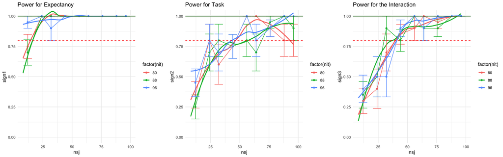

```r
power_plots_items(COF_large_effects)
```

Plot for the smallest effects:

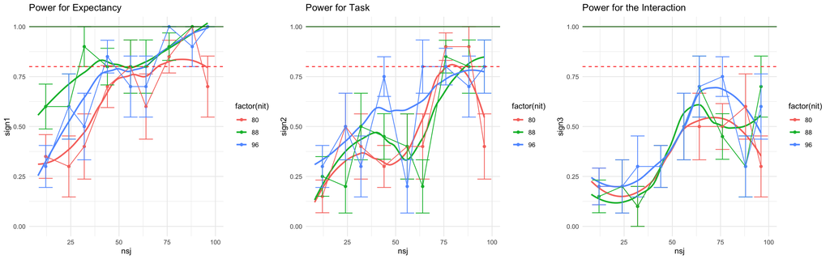

```r
power_plots_items(COF_small_effects)
```

### 3.2.3 Power by N of subjects & effect size

```r
power_plots_effects <- function(dat) {

  # Extract maximal y axis range to make the two plots comparable side by side
  y_range <- range(c(dat$sign1, dat$sign2, dat$sign3), na.rm = TRUE)

  p1 <- ggplot(data=dat) +
    geom_smooth(aes(x=nsj, y=sign1, color=factor(exp), fill=factor(exp)),
                method="loess", se=TRUE)+
    geom_point(   stat="summary", aes(x=nsjFL, y=sign1, colour=factor(exp)))+
    geom_errorbar(stat="summary", aes(x=nsjFL, y=sign1, colour=factor(exp)))+
    geom_line(    stat="summary", aes(x=nsjFL, y=sign1, colour=factor(exp)))+
    geom_hline(yintercept = 0.8, color = "red", linetype = "dashed") +
    geom_hline(yintercept = 1, color = "darkgreen", linetype = "solid") +
    ggtitle("Power for Expectancy") +
    theme_minimal()

  p2 <- ggplot(data=dat) +
    geom_smooth(aes(x=nsj, y=sign2, color=factor(task), fill=factor(task)),
                method="loess", se=TRUE)+
    geom_point(   stat="summary", aes(x=nsjFL, y=sign2, colour=factor(task)))+
    geom_errorbar(stat="summary", aes(x=nsjFL, y=sign2, colour=factor(task)))+
    geom_line(    stat="summary", aes(x=nsjFL, y=sign2, colour=factor(task)))+
    geom_hline(yintercept = 0.8, color = "red", linetype = "dashed") +
    geom_hline(yintercept = 1, color = "darkgreen", linetype = "solid") +
    ggtitle("Power for Task") +
    theme_minimal()

  p3 <- ggplot(data=dat) +
    geom_smooth(aes(x=nsj, y=sign3, color=factor(interact), fill=factor(interact)),
                method="loess", se=TRUE)+
    geom_point(   stat="summary", aes(x=nsjFL, y=sign3, colour=factor(interact)))+
    geom_errorbar(stat="summary", aes(x=nsjFL, y=sign3, colour=factor(interact)))+
    geom_line(    stat="summary", aes(x=nsjFL, y=sign3, colour=factor(interact)))+
    geom_hline(yintercept = 0.8, color = "red", linetype = "dashed") +
    geom_hline(yintercept = 1, color = "darkgreen", linetype = "solid") +
    ggtitle("Power for the Interaction") +
    theme_minimal()

  p1 <- p1 + coord_cartesian(ylim = y_range)
  p2 <- p2 + coord_cartesian(ylim = y_range)
  p3 <- p3 + coord_cartesian(ylim = y_range)

  suppressMessages({
    gridExtra::grid.arrange(p1, p2, p3, nrow = 1)
  })
}
```

Plot for the maximal number of items:

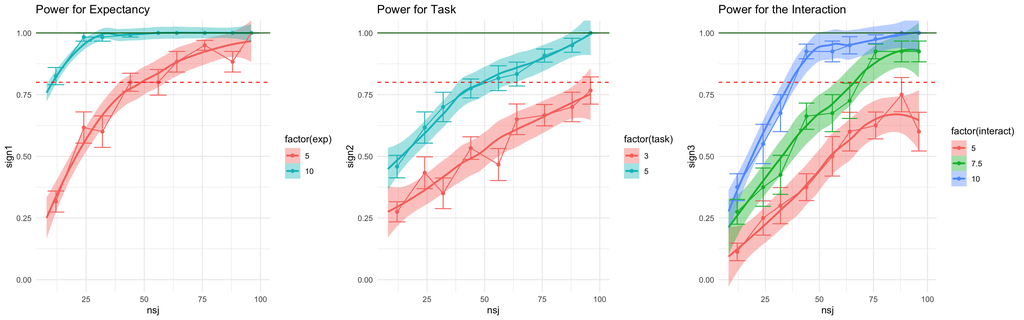

```r
COF_max_items <- filter(COF, nit == max(nit))
power_plots_effects(COF_max_items)
```

Plot for the minimal number of items:

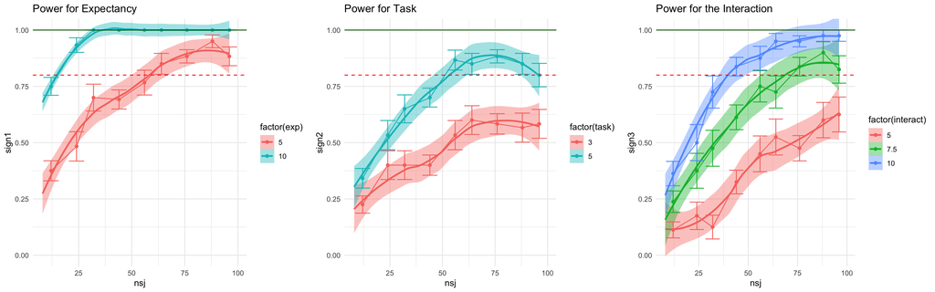

```r
COF_min_items <- filter(COF, nit == min(nit))
power_plots_effects(COF_min_items)
```

## 3.3 N subjects needed to reach 80% power

Determine the number of subjects needed for each effect to reach a power of 80%:

```r
power_threshold <- function(effect_name, effect_vector, sign) {
  for (i in 1:length(effect_vector)) {
    current <- effect_vector[i]
    COF_current <- filter(COF, eval(parse(text=effect_name))==current)

    m0 <- loess(eval(parse(text=sign)) ~ nsj, data=COF_current)
    COF$pred <- predict(m0)
    idx <- COF$pred>0.8
    min_effect <- ifelse(length(COF$nsj[idx]) > 0, min(COF$nsj[idx]), FALSE)

    cat("Effect size:", current,
      "-> min required subjects:",
      min_effect, sep=" ", end="\n\n")
  }
}
```

```r
print("Expectancy:")
```

```
## [1] "Expectancy:"
```

```r
power_threshold("exp", expectancy_fixed, "sign1")
```

```
## Effect size: 5 -> min required subjects: 32
##
## Effect size: 10 -> min required subjects: 8
```

```r
print("Task:")
```

```
## [1] "Task:"
```

```r
power_threshold("task", task_fixed, "sign2")
```

```
## Effect size: 3 -> min required subjects: FALSE
##
## Effect size: 5 -> min required subjects: 32
```

```r
print("Expectancy-Task Interaction:")
```

```
## [1] "Expectancy-Task Interaction:"
```

```r
power_threshold("interact", interaction_fixed, "sign3")
```

```
## Effect size: 5 -> min required subjects: FALSE
##
## Effect size: 7.5 -> min required subjects: 24
##
## Effect size: 10 -> min required subjects: 16
```